# chapter1

kuldeep parashar

29 June 2018

# Chapter1

tidying means making the data consisten enough and transforming means making more variable from the initial one on which we can count or are the one which are field of intrest but not directly derivable both this process as sum is known as data wrangling and a very important part of data sccience so must be pad attection on it

after this we have two resource to draw knowledge or insiht from the data by visulising nd by modelling both have some cons and pros and this thing acta s cycle till we reach the optimal level after that all the knowledge is give as a presentation or as a dynamic app or presentation

Basically the data problem can occur in 3 ways:- its just a 2;3 gb data can be easily handled by r its 10-100 gb of data big.table other then this may be not need that big data only need summry and all may be only so keep in mind to find the correct subset to answer a particular Question it may also be possible that the data can be act a small chunks ,which are independent and can br computed alone so here we would use sparklr or big data

##### models are often used for exploration, and with a little care you can use visualisation for confirmation.

so here we can do data exploration,transformation ,=and modelling first we start with modelling and using the ggplot2 library we will use the dataframe from ggplot2 pacakge name mpg

now we will plot usinf ggplot library

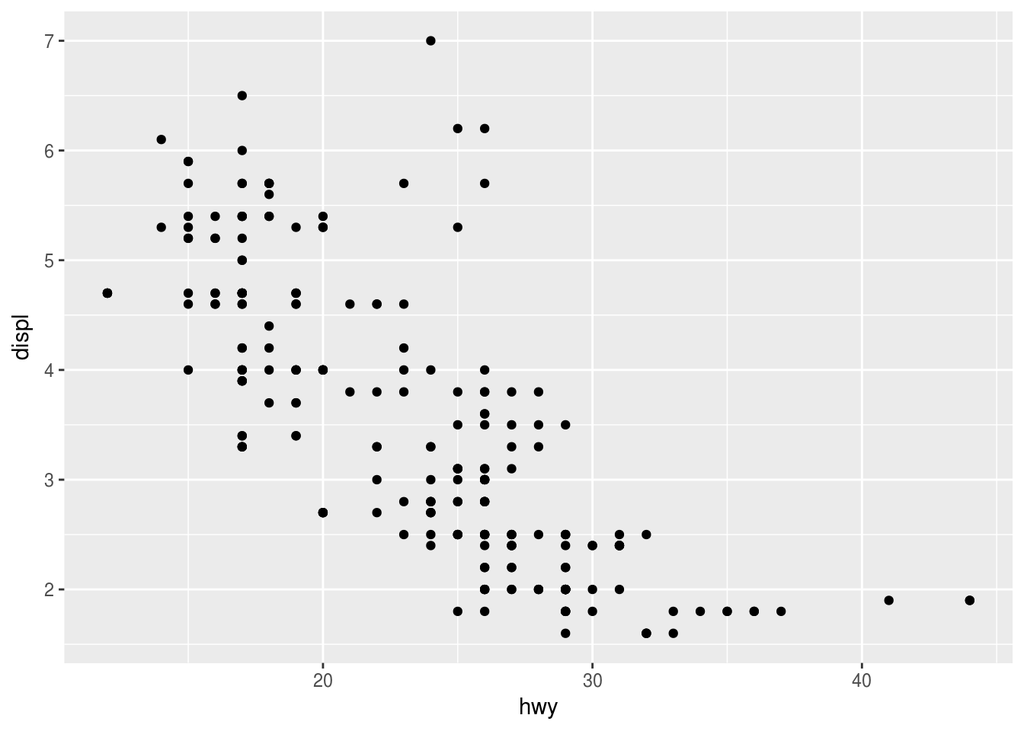

```r
ggplot(data=mpg,aes(y=displ,x=hwy))+geom_point()
```

so its the first plot of the book and wel know and great even

```r
 dim(mpg)
```

```
## [1] 234  11
```

```r
summary(mpg)
```

```
##  manufacturer          model               displ            year
##  Length:234         Length:234         Min.   :1.600   Min.   :1999
##  Class :character   Class :character   1st Qu.:2.400   1st Qu.:1999
##  Mode  :character   Mode  :character   Median :3.300   Median :2004
##                                        Mean   :3.472   Mean   :2004
##                                        3rd Qu.:4.600   3rd Qu.:2008
##                                        Max.   :7.000   Max.   :2008
##       cyl           trans               drv                 cty
##  Min.   :4.000   Length:234         Length:234         Min.   : 9.00
##  1st Qu.:4.000   Class :character   Class :character   1st Qu.:14.00
##  Median :6.000   Mode  :character   Mode  :character   Median :17.00
##  Mean   :5.889                                         Mean   :16.86
##  3rd Qu.:8.000                                         3rd Qu.:19.00
##  Max.   :8.000                                         Max.   :35.00
##       hwy             fl               class
##  Min.   :12.00   Length:234         Length:234
##  1st Qu.:18.00   Class :character   Class :character
##  Median :24.00   Mode  :character   Mode  :character
##  Mean   :23.44
##  3rd Qu.:27.00
##  Max.   :44.00
```

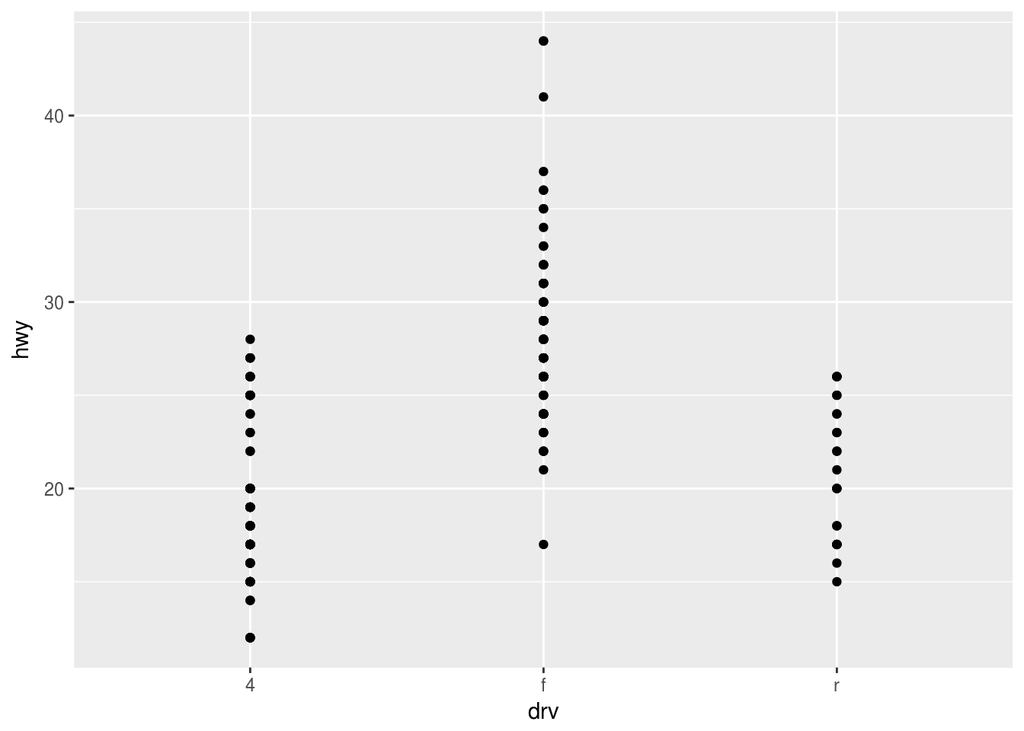

```r
ggplot(data=mpg,aes(x=drv,y=hwy))+geom_point()
```

now after this we are going to changw the aesthetic properties of the data points, these properties could be the shape size and colour of the data point , all these can be changed inthe aesthetic part of the ggplot

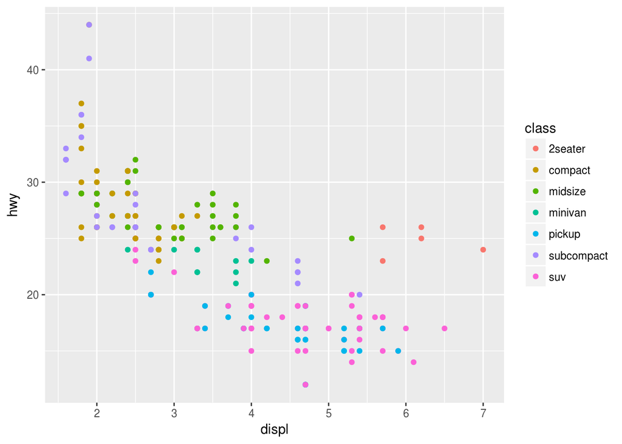

```r
ggplot(data=mpg,aes(x=displ,y=hwy,color=class))+geom_point()
```

in above we had used the color aesthtic to make the graph but we can use the size aesthetic too to make it a greart thing but in this scinario its not a great idea, infact its a bad one as we know that for this case its bbatter that all are categorical

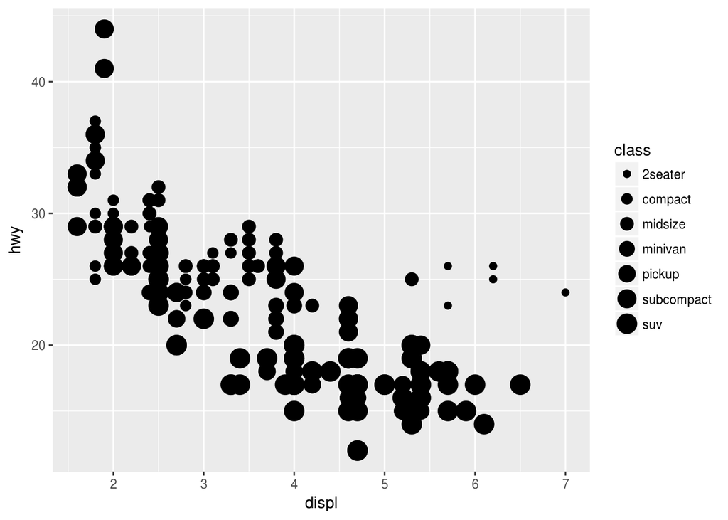

```r
ggplot(data = mpg) +
  geom_point(mapping = aes(x = displ, y = hwy, size = class))
```

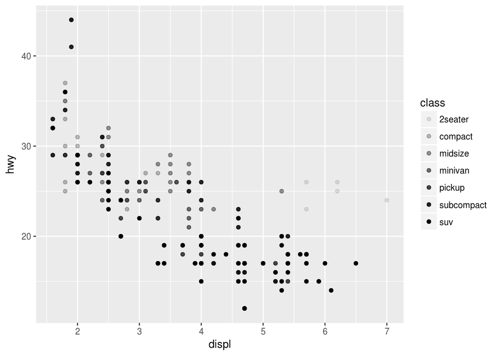

```r
# Left
ggplot(data = mpg) +
  geom_point(mapping = aes(x = displ, y = hwy, alpha = class))
```

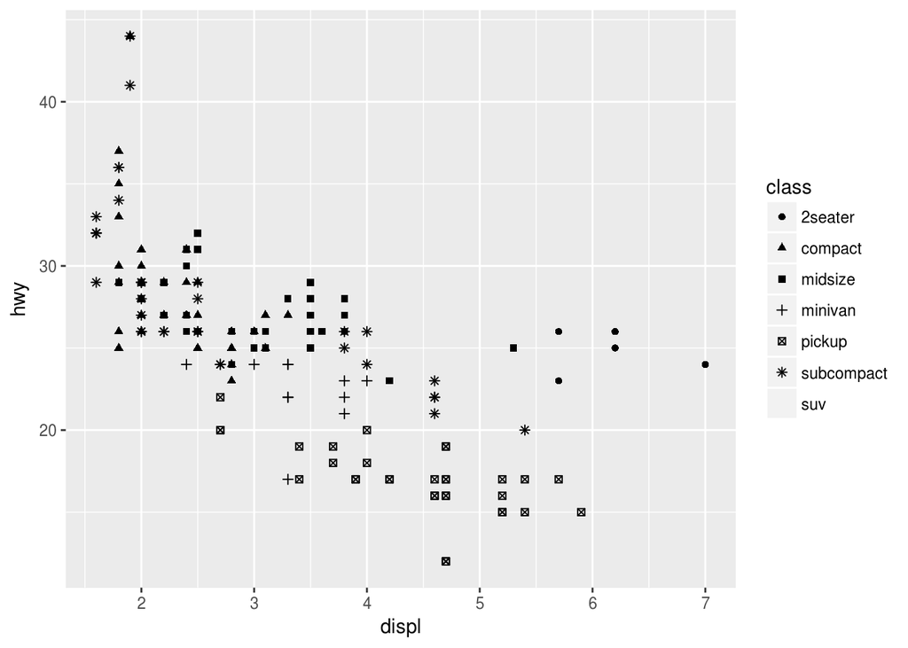

```r
# Right
ggplot(data = mpg) +
  geom_point(mapping = aes(x = displ, y = hwy, shape = class))
```

so here is limitation of using the shape aesthetic it can max distinguish only 6 aes

and also behind the scene the aes function is mapping the x and y given to it and then create a visual layer add legends to it and create axis as per the data points we can manully do this using

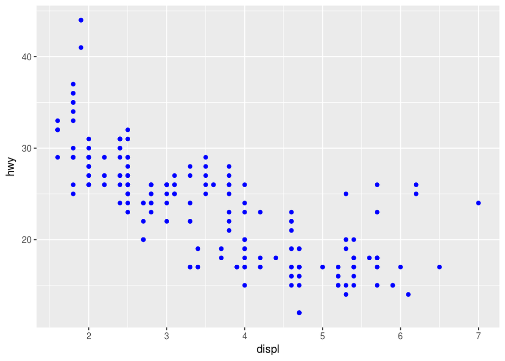

```r
ggplot(data = mpg) +
  geom_point(mapping = aes(x = displ, y = hwy), color = "blue")
```

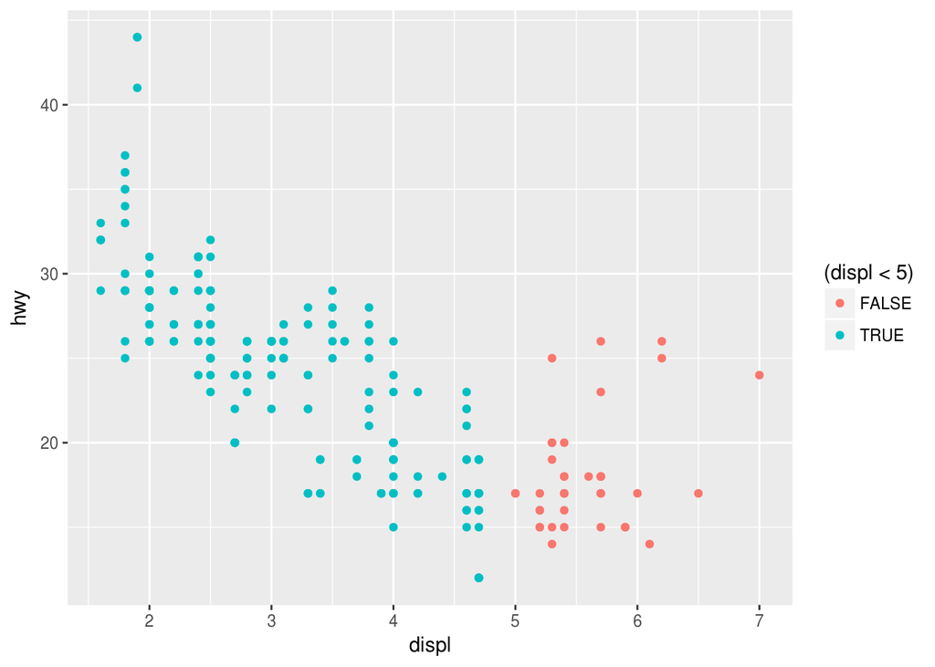

```r
ggplot(data=mpg)+geom_point(mapping = aes(x = displ, y = hwy,color=(displ<5) ))
```

### facet_wrap()

can be used to make subplot based on some categorical value, sothat we can individual or cattegoricaly study these all

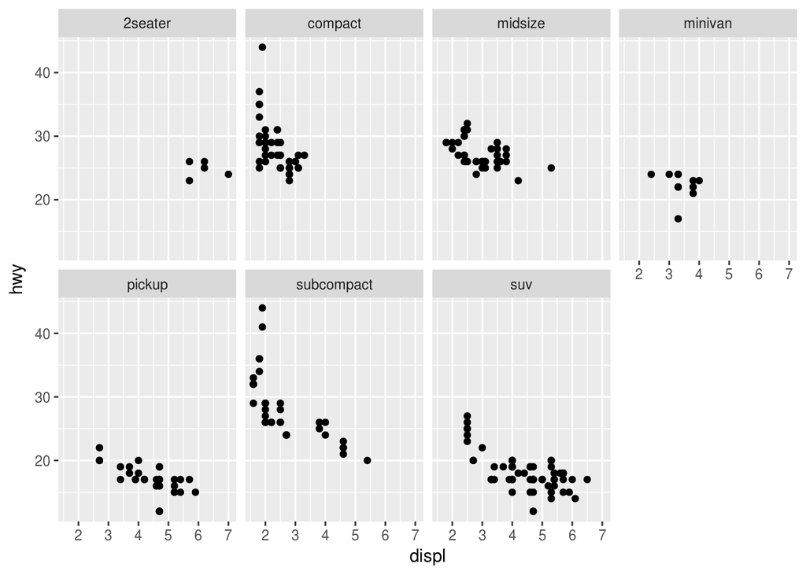

```r
ggplot(data=mpg,aes(x=displ,y=hwy))+geom_point()+facet_wrap(~class,nrow = 2)
```

here we are being able to see the plot based on each category if we want to make grph on basis of combination of two then we use facet_grid() both these have only few categorn so easy to view

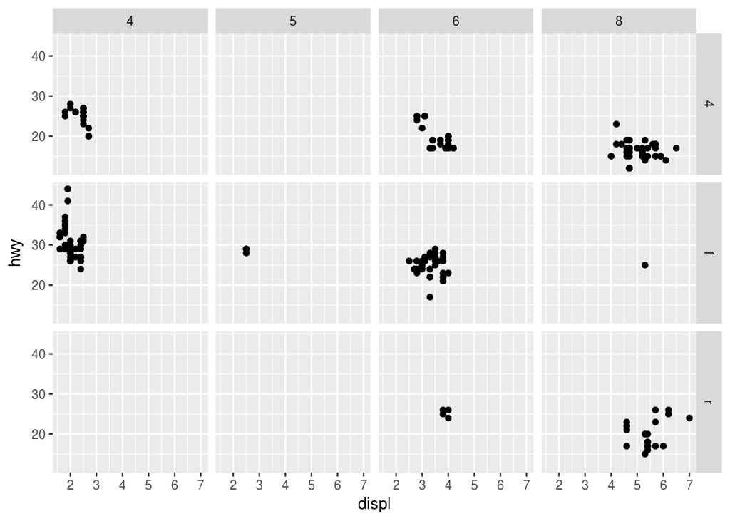

```r
ggplot(data=mpg,aes(x=displ,y=hwy))+geom_point()+facet_grid(drv~cyl)
```

lets try examples too

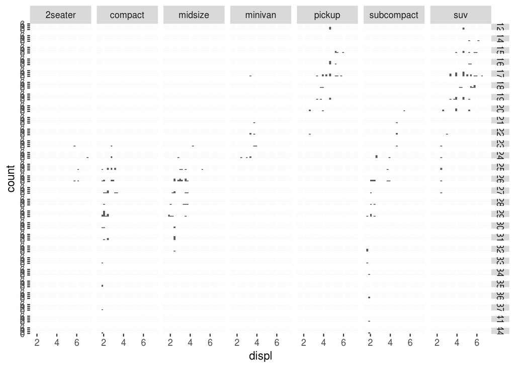

```r
ggplot(data=mpg,aes(x=displ))+geom_histogram()+facet_grid(hwy~class)
```

no this plot is hactic rather than any other thing so keep in mind not o use continious var for facet_grid and is use make bin size large or the data rane must be low

we can plot same x and y with different geom function too and like for pointplot and smooth these are ploteed on same data but from different

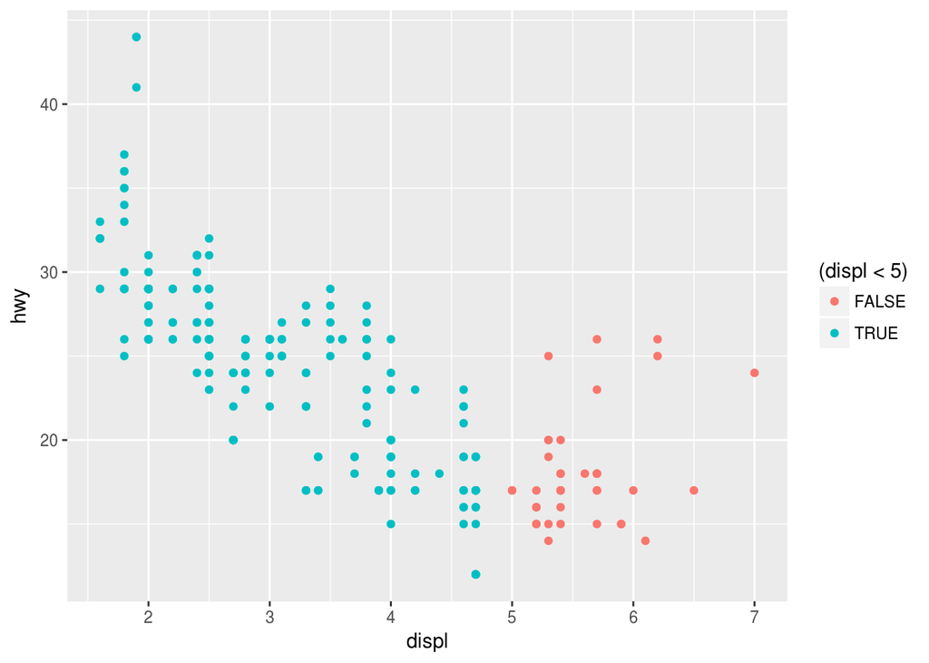

```r
ggplot(data=mpg)+geom_point(mapping = aes(x = displ, y = hwy,color=(displ<5) ))
```

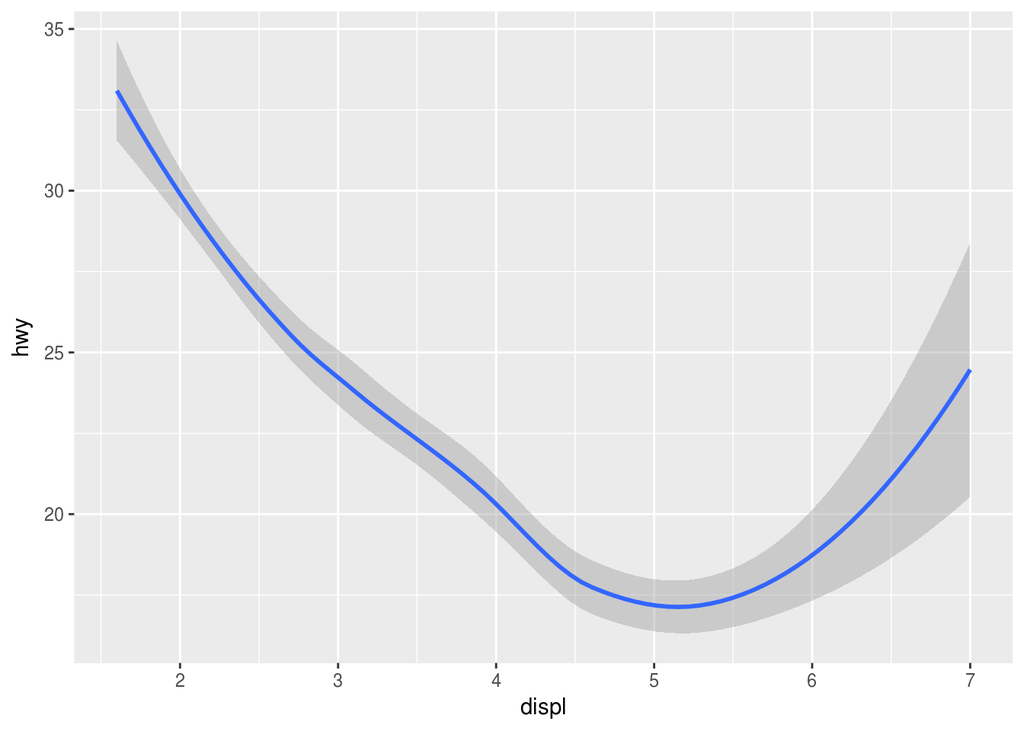

```r
ggplot(data=mpg)+geom_smooth(mapping = aes(x = displ, y = hwy ))
```

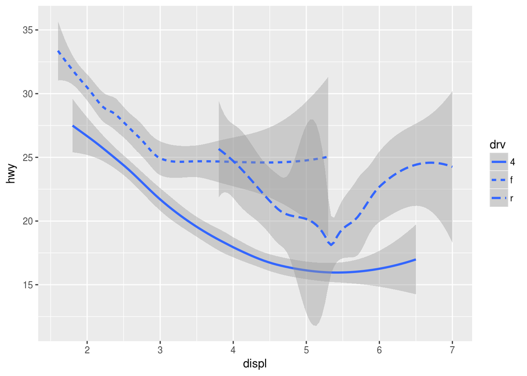

```r
ggplot(data = mpg)+geom_smooth(mapping = aes(x = displ, y = hwy, linetype = drv))
```

so by adding layer we can make graphs containg differnt geom object but its also came up of redundancy that if we wanrt to change only 1 legend it must be changed in bot

## solution>

try to gve mapping to at once to ggplot and after that change the filters or the relevant layers

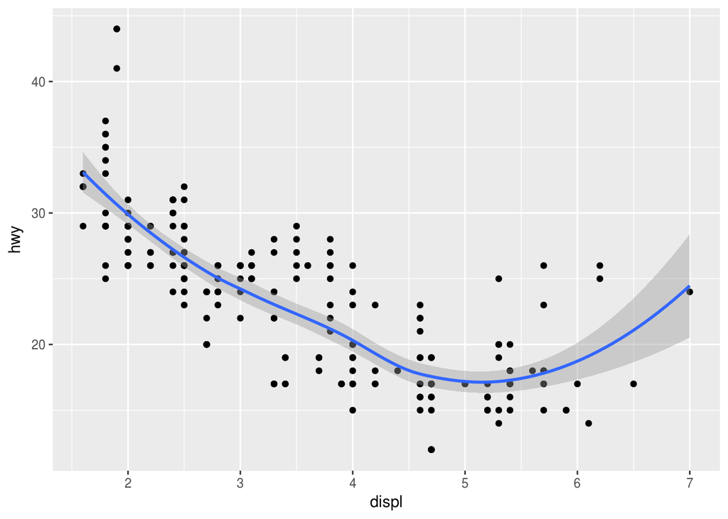

```r
####the redundant way
ggplot(data = mpg) +
  geom_point(mapping = aes(x = displ, y = hwy)) +
  geom_smooth(mapping = aes(x = displ, y = hwy))
```

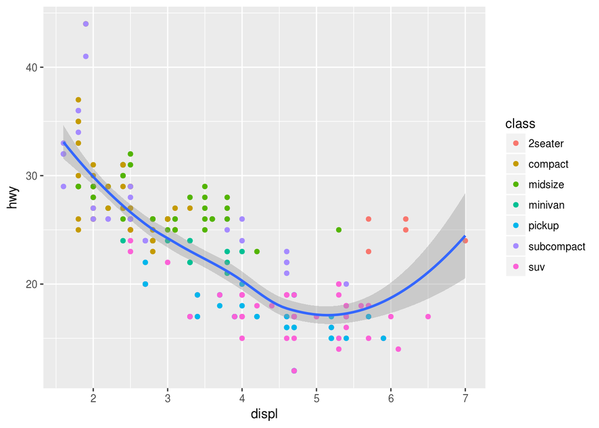

```r
######################################################### non redundant way
ggplot(data = mpg, mapping = aes(x = displ, y = hwy)) +
  geom_point(mapping = aes(color = class)) +
  geom_smooth()
```

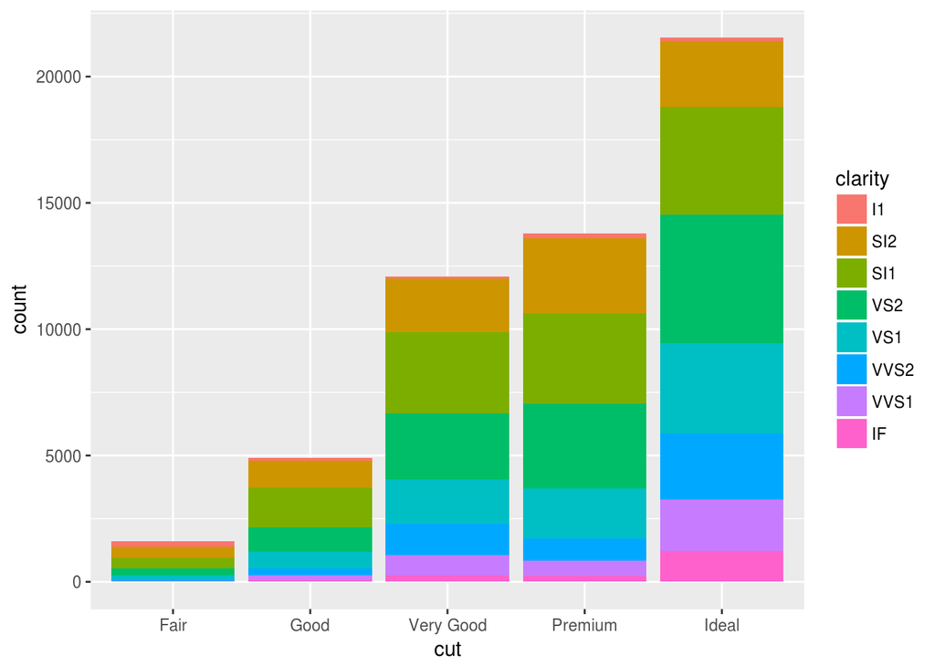

```r
ggplot(data = diamonds) +
  geom_bar(mapping = aes(x = cut, fill = clarity))
```

```r
  seq(1,10,length.out = 5)
```

```
## [1]  1.00  3.25  5.50  7.75 10.00
```

```r
y<-seq(1,10,length.out = 5)
```

filter is used for filtring the data on some certain condition

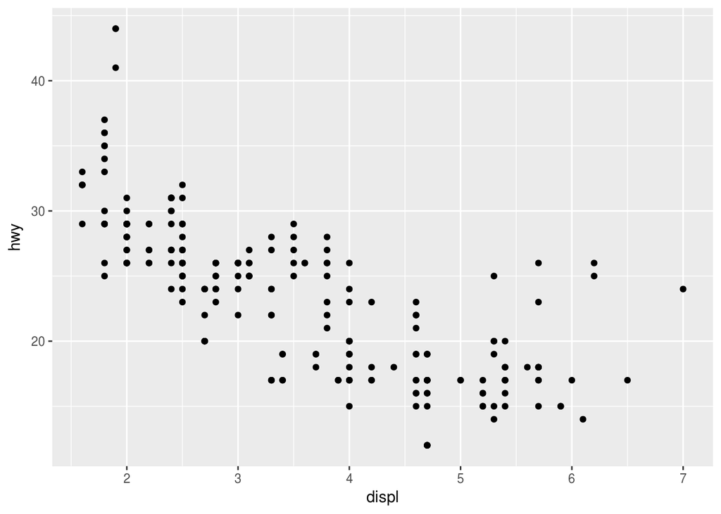

```r
library(tidyverse)
ggplot(data=mpg)+geom_point(mapping = aes(x=displ,y=hwy))
```

```r
filter(mpg,cyl==8)
```

```
## # A tibble: 70 x 11
##    manufa… model    displ  year   cyl trans  drv     cty   hwy fl    class
##    <chr>   <chr>    <dbl> <int> <int> <chr>  <chr> <int> <int> <chr> <chr>
##  1 audi    a6 quat…  4.20  2008     8 auto(… 4        16    23 p     mids…
##  2 chevro… c1500 s…  5.30  2008     8 auto(… r        14    20 r     suv
##  3 chevro… c1500 s…  5.30  2008     8 auto(… r        11    15 e     suv
##  4 chevro… c1500 s…  5.30  2008     8 auto(… r        14    20 r     suv
##  5 chevro… c1500 s…  5.70  1999     8 auto(… r        13    17 r     suv
##  6 chevro… c1500 s…  6.00  2008     8 auto(… r        12    17 r     suv
##  7 chevro… corvette  5.70  1999     8 manua… r        16    26 p     2sea…
##  8 chevro… corvette  5.70  1999     8 auto(… r        15    23 p     2sea…
##  9 chevro… corvette  6.20  2008     8 manua… r        16    26 p     2sea…
## 10 chevro… corvette  6.20  2008     8 auto(… r        15    25 p     2sea…
## # ... with 60 more rows
```

```r
filter(diamonds,carat>5)
```

```
## # A tibble: 1 x 10
##   carat cut   color clarity depth table price     x     y     z
##   <dbl> <ord> <ord> <ord>   <dbl> <dbl> <int> <dbl> <dbl> <dbl>
## 1  5.01 Fair  J     I1       65.5  59.0 18018  10.7  10.5  6.98
```